# Lab2

September 7, 2019

## Topics

- added variable plots `avPlots` from `library(car)`
- `termplot` Base R
- `boxCox` from `library(car)`
- `powerTransform` from `library(car)`

## Interpretation with Multiple Regression: Added Variable Plots

- Regression Coefficients in Multiple Regression are adjusted for other variables
- use the United Nations data ‘full’ model

$$E[\log(\text{Fertility}) \mid \log(\text{PPgdp}) = x_1, \text{Purban} = x_2) = \beta_0 + \beta_1 x_1 + \beta_2 x_2$$

- Keeping `Purban` fixed, with a one unit change in `log(PPgdp)` we expect `log(Fertility)` to change by $\beta_1$
- Visualize with added-variable plots

## Data and Cleaning

```r
data(UN3, package="alr3")
UN = dplyr::select(UN3, c(Fertility, PPgdp, Purban)) %>%
  mutate(logPPgdp = log(PPgdp),
         logFertility = log(Fertility)) %>%
  na.omit()
```

## Scatter plots

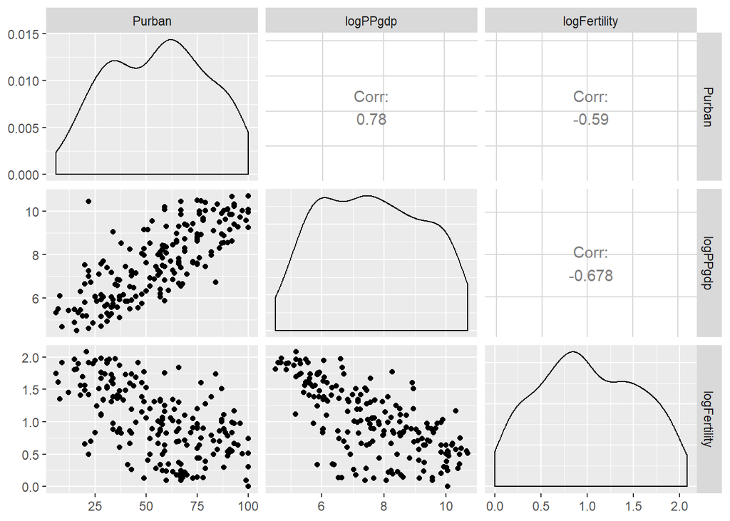

```r
ggpairs(UN, c(3,4,5))
```

## Adjustment for `Purban`

1. Regress `log(Fertility)` on `Purban` and obtain the residuals; call them `e_Y` for example.

```r
e_Y = residuals(lm(logFertility ~ Purban, data=UN))
```

2. Regress `logPPgdp` on `Purban` and obtain the residuals (call `e_X1`)

```r
e_X1 = residuals(lm(logPPgdp ~ Purban, data=UN))
```

3. regress `e_Y` on `e_X`
4. slope is the same as the estimated slope for `logPPgdp` in the full model with both predictors.

## Added Variable Plot

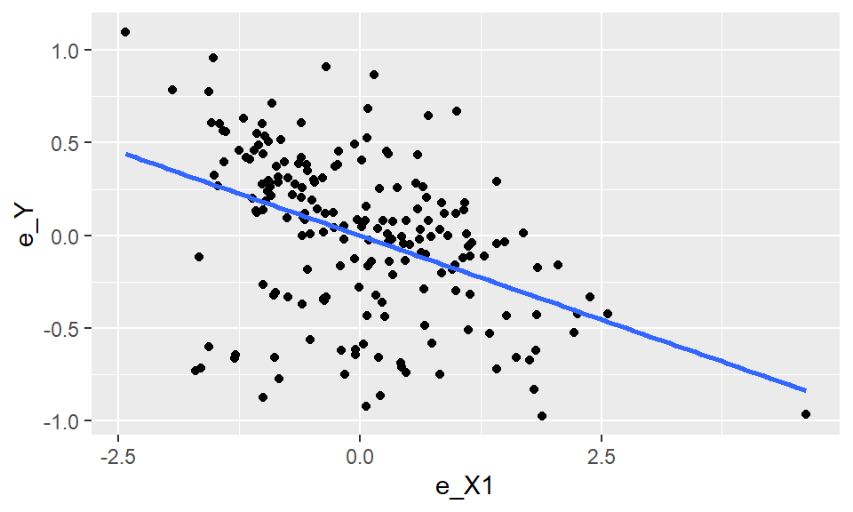

```r
df = data.frame(e_Y = e_Y, e_X1 = e_X1)
ggplot(data=df, aes(x = e_X1, y = e_Y)) +
  geom_point() +
  geom_smooth(method = "lm", se = FALSE)
```

## Compare

```r
summary(lm(logFertility ~ logPPgdp + Purban, data=UN))$coef
```

```
##                 Estimate  Std. Error   t value     Pr(>|t|)
## (Intercept)  2.592995920 0.146863770 17.655790 6.326423e-42
## logPPgdp    -0.181022345 0.027547933 -6.571177 4.673094e-10
## Purban      -0.003522218 0.001884399 -1.869147 6.314122e-02
```

```r
summary(lm(e_Y ~ e_X1, data=df))$coef
```

```
##                  Estimate Std. Error       t value     Pr(>|t|)
## (Intercept) -7.991560e-18 0.02825961 -2.827909e-16 1.000000e+00
## e_X1        -1.810223e-01 0.02747572 -6.588447e+00 4.207703e-10
```

- coefficients are the same
- residuals are the same
- t-values not quite (why?)

## In General `avPlots`

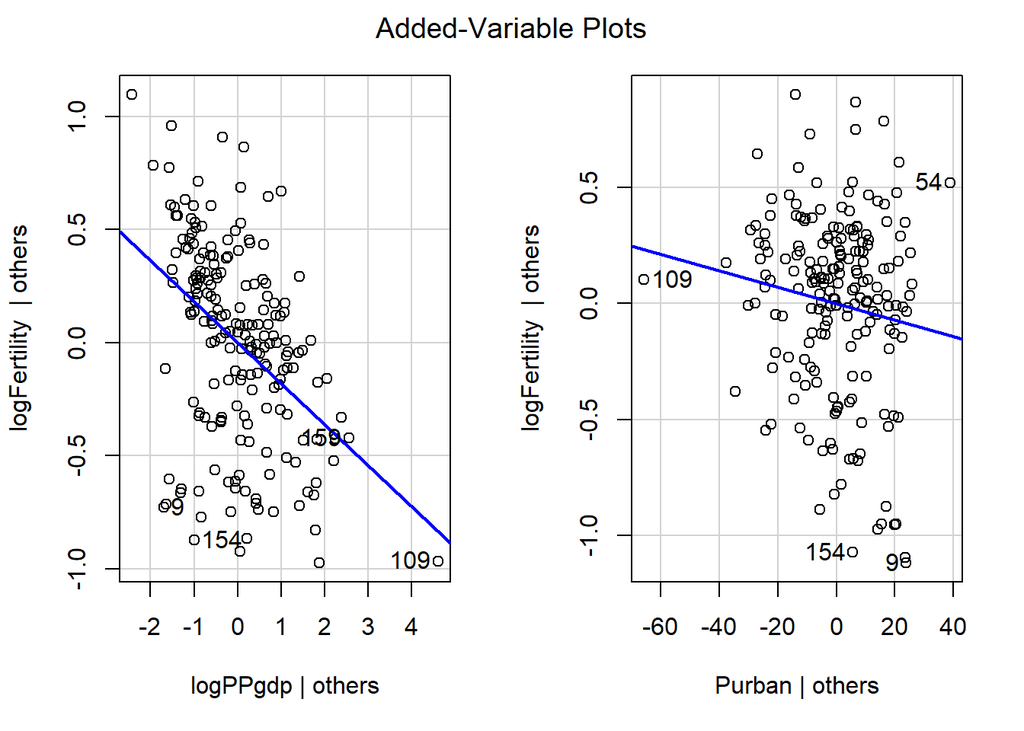

```r
car::avPlots(lm(logFertility ~ logPPgdp + Purban, data=UN))
```

## Added Variable Plot Example & Transformations

```r
n = 100
logx1 = rnorm(n)
x1 = exp(logx1)
x2 = abs(rnorm(n))
logy = .5 + 3*logx1 - 2*sqrt(x2) + rnorm(n)
simdat = data.frame(X1=x1, X2 = x2, Y=exp(logy))
```

```r
library(car)
```

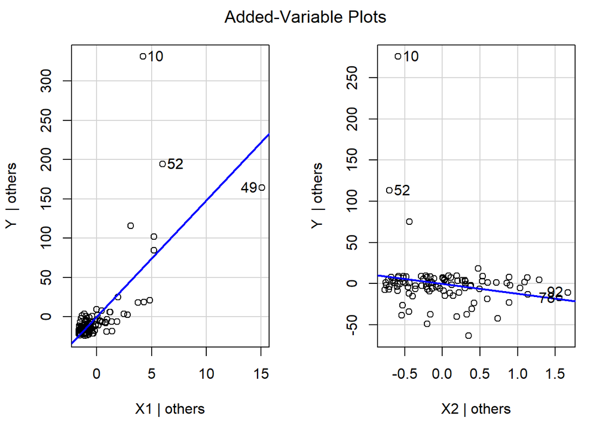

```r
mod1 = lm(Y ~ X1 + X2, data=simdat)
avPlots(mod1)
```

In the added variable plot, (like termplot below) this can also show if the linear term in $X1$ is appropriate or perhaps there is a nonlinear relationship or if there are outliers or influential points that affect the adjusted relationship.

## Transformations

```r
data("Prestige")
```

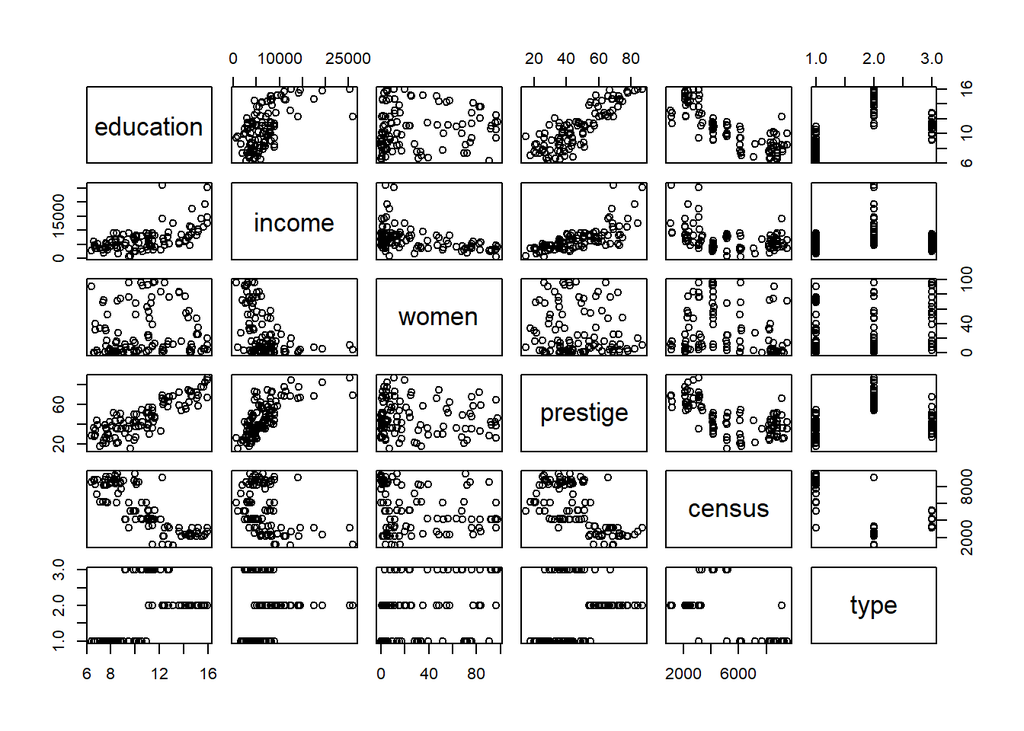

```r
pairs(Prestige)
```

### BoxCox

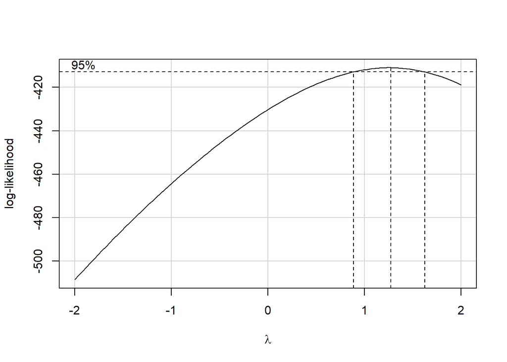

```r
car::boxCox(lm(prestige ~ income + education + type + poly(women, 2), data=Prestige))
```

see `help(boxCox)` for generalizations for non-positive responses

### PowerTransform

```r
car::powerTransform(Prestige[, 1:5], family="bcnPower")
```

```
## Estimated transformation power, lambda
## [1] -3.0000000 -0.3642918  0.2648833 -0.7843970  0.7357956
##
## Estimated location, gamma
## [1]  333.786095 4656.422568    0.100000 1106.672731    0.155926
```

```r
#omit type last column as it is discrete
# allow non-positive values
#
# see help(powerTransform) for examples and testing for "nice" powers
```

## Termplot output

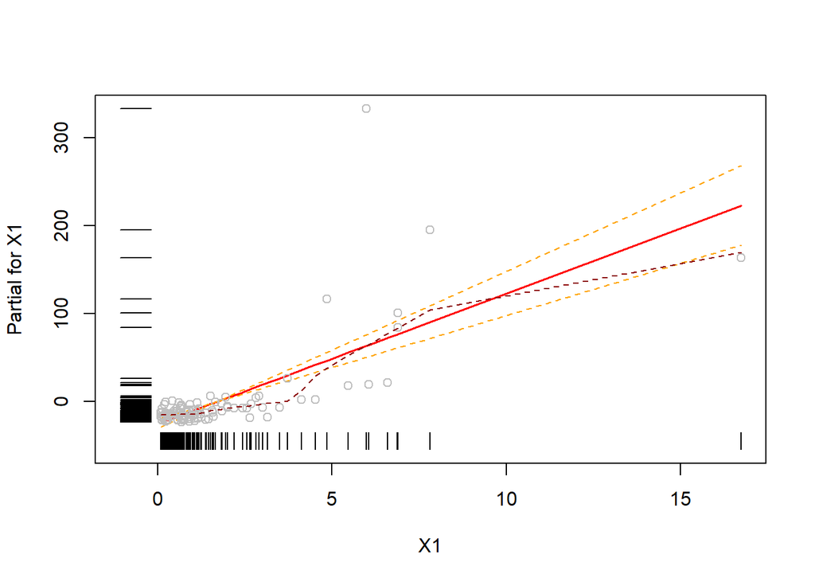

```r
termplot(lm(Y ~ X1 + X2, data=simdat), terms = "X1",
         partial.resid = T, se=T, rug=T,
         smooth = panel.smooth)
```

## Termplot output

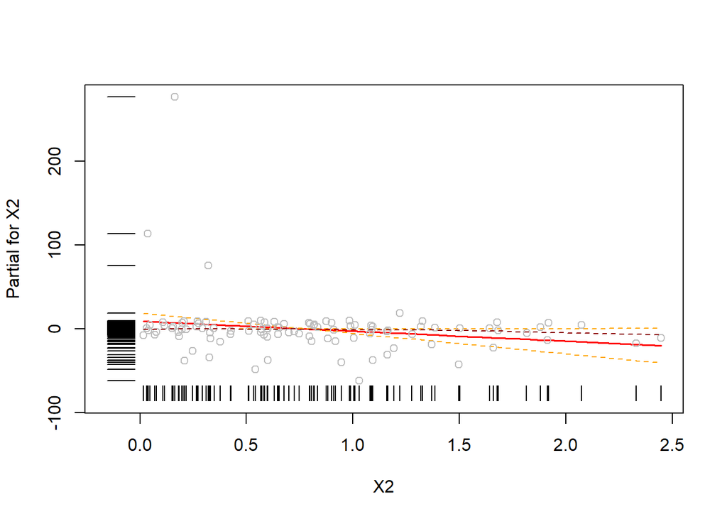

```r
termplot(lm(Y ~ X1 + X2, data=simdat), terms = "X2",
         partial.resid = T, se=T, rug=T,
         smooth = panel.smooth)
```

## termplot with transformation of Y and X1

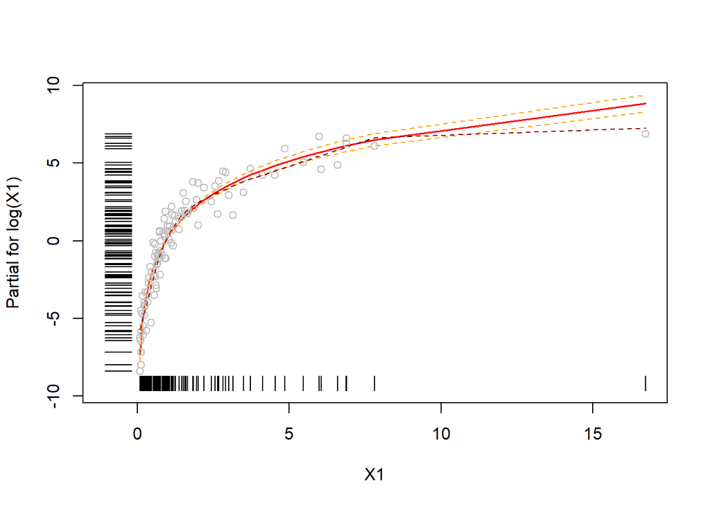

```r
termplot(lm(log(Y) ~ log(X1) + X2, data=simdat),
         terms = "log(X1)", partial.resid = T, se=T, rug=T,
         smooth = panel.smooth)
```

## termplot with transformation of Y and X1

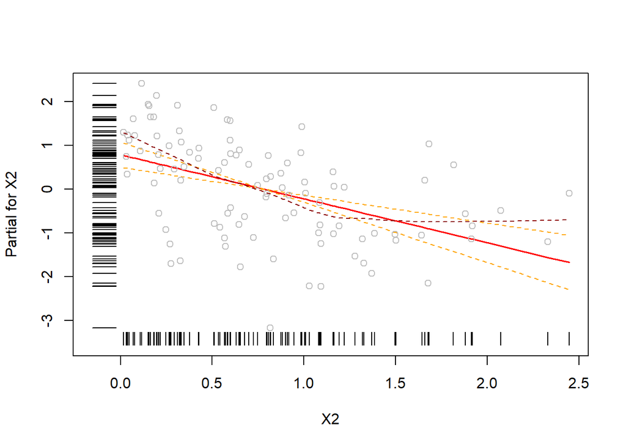

```r
termplot(lm(log(Y) ~ log(X1) + X2, data=simdat), terms = "X2",
         partial.resid = T, se=T, rug=T, smooth = panel.smooth)
```

## termplot with transformation of Y, X1, and X2

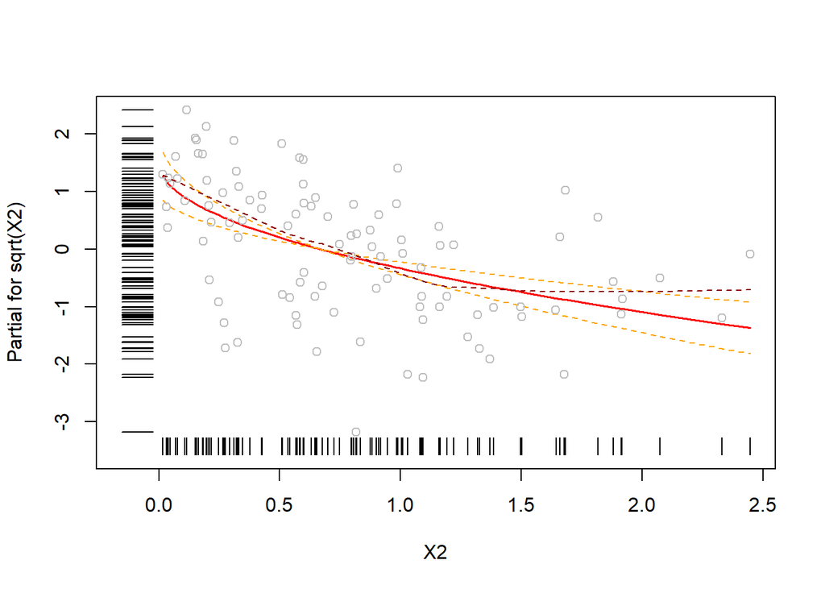

```r
termplot(lm(log(Y) ~ log(X1) + sqrt(X2), data=simdat), terms = "sqrt(X2)",
         partial.resid = T, se=T, rug=T, smooth = panel.smooth)
```

## What is in a term plot?

- x-axis is the (untransformed) variable in your dataframe $(X1, X2)$
- line is the “term” of that variable’s contribution to $f(x)$
- y-axis is partial residuals for term
- `partial.resid = T` adds the partial residuals to the plot
- `rug = T` shows location of data on axes
- `se = T` adds the SE of the term’s contribution to $f(x)$
- `smooth = panel.smooth` adds “smoothed” means to plot

## Terms

$$Y = \hat{\beta}_0 + \hat{\beta}_1 X1 + \hat{\beta}_2 X2 + e$$
Equivalent to centered model

$$Y = \bar{Y} + \hat{\beta}_1 (X1 - \bar{X1}) + \hat{\beta}_2 (X2 - \bar{X2}) + e$$
Terms are coefficient estimates times centered predictors
$$\hat{\beta}_1 (X1 - \bar{X1})$$
$$\hat{\beta}_2 (X2 - \bar{X2})$$

## Terms with transformations

$$\log(Y) = \hat{\beta}_0 + \hat{\beta}_1 \log(X1) + \hat{\beta}_2 X2 + e$$
Equivalent to centered model

$$\log(Y) = \bar{\log(Y)} + \hat{\beta}_1 (\log(X1) - \bar{\log(X1)}) + \hat{\beta}_2 (X2 - \bar{X2}) + e$$
Terms are coefficient estimates times centered “predictors”
$$\hat{\beta}_1 (\log(X1) - \bar{\log(X1)})$$

## partial residuals for a term

$$\log(Y) = \bar{\log(Y)} + \hat{\beta}_1 (\log(X1) - \bar{\log(X1)}) + \hat{\beta}_2 (X2 - \bar{X2}) + e$$

$$\log(Y) - (\bar{\log(Y)} + \hat{\beta}_1 (\log(X1) - \bar{\log(X1)})) = \hat{\beta}_2 (X2 - \bar{X2}) + e$$

- Lefthand side takes response and removes the part of the response that is explained by $X1$
- Equal to the `term` for $X2$ plus the residual $e$
- part of residual variation that is not explained by the other terms that potentially can be explained by $X2$ = partial residual for $X2$
- partial residual for X1

$$\hat{\beta}_1 (\log(X1) - \bar{\log(X1)}) + e$$
(add back in term to residual to obtain partial residual)

## Summary

- Linear predictors may be based on functions of other predictors (dummy variables, interactions, non-linear terms)
- need to change back to original units
- log transform useful for non-negative responses (ensures predictions are non-negative)
- Be careful of units of data + plots should show units + summary statements should include units
- Goodness of fit measure: $R^2$ and Adjusted $R^2$ depend on scale $R^2$ is percent variation in “$Y$” that is explained by the model
  $$R^2 = 1 - SSE/SST$$
  where SST = $\sum_i (Y_i - \bar{Y})^2$